# Bike Share Case Study - 3 - Analysis

Now let’s look at the same plot for classic bikes.

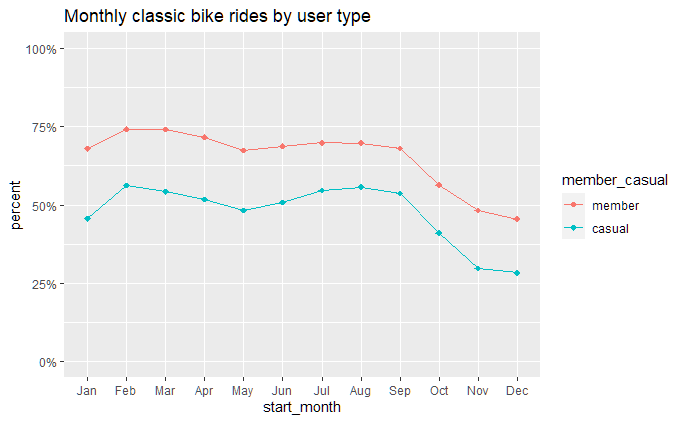

```r
bike_share %>%
  group_by(start_month, rideable_type, member_casual) %>%
  summarize(ride_count = n(), .groups = "keep") %>%
  group_by(start_month, member_casual) %>%
  mutate(percent = ride_count / sum(ride_count)) %>%
  filter(rideable_type == "classic_bike") %>%
  ggplot(mapping = aes(x = start_month, y = percent, group = member_casual)) +
  geom_line(mapping = aes(color = member_casual)) +
  geom_point(mapping = aes(color = member_casual), size = 2, shape = 18) +
  scale_y_continuous(labels = scales::percent) +
  coord_cartesian(ylim = c(0, 1)) +
  ggtitle(label = "Monthly classic bike rides by user type")
```

Changes in classic bike use are also correlated between the two user groups. Since the groups use electric bikes at nearly the same percentages, the difference in use of classic bikes is mostly due to the use of docked bikes by casual riders.

Let’s compare the percentages of casual rides for classic and docked bikes only.

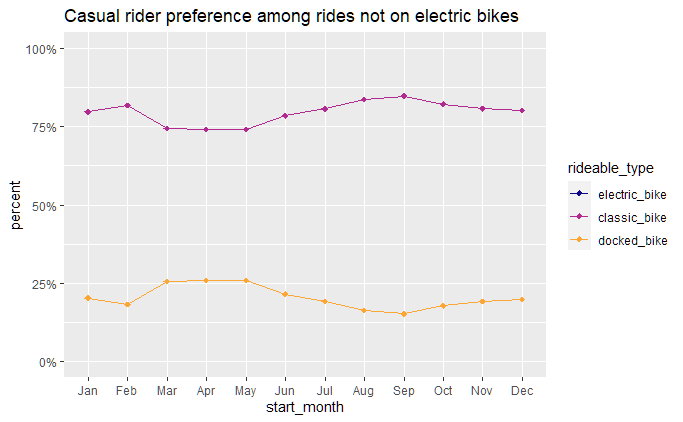

```r
bike_share %>%
  filter(member_casual == "casual" & rideable_type != "electric_bike") %>%
  group_by(start_month, rideable_type) %>%
  summarize(ride_count = n(), .groups = "keep") %>%
  group_by(start_month) %>%
  mutate(percent = ride_count / sum(ride_count)) %>%
  ggplot(mapping = aes(x = start_month, y = percent, group = rideable_type)) +
  geom_line(mapping = aes(color = rideable_type)) +
  geom_point(mapping = aes(color = rideable_type), size = 2, shape = 18) +
  scale_y_continuous(labels = scales::percent) +
  scale_color_viridis_d(option = "plasma", end = 0.8, drop = FALSE) +
  coord_cartesian(ylim = c(0, 1)) +
  ggtitle(label = "Casual rider preference among rides not on electric bikes")
```

This plot shows that casual riders consistently use docked bikes about 15 to 25% of the time when they don’t use electric bikes. Whether this is due to user preference, bike availability, or something else can’t be determined without information beyond what’s in the data set.

Let’s see whether the day of the week affects the type of bike used by members.

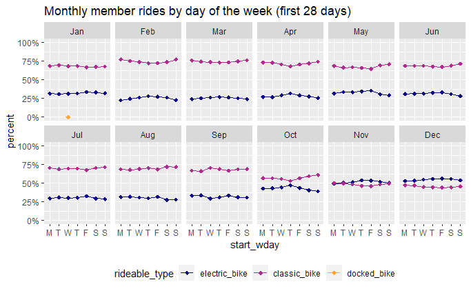

```r
bike_share %>%
  filter(member_casual == "member" & start_mday < 29) %>%
  group_by(rideable_type, start_wday, start_month) %>%
  summarize(ride_count = n(), .groups = "keep") %>%
  group_by(start_wday, start_month) %>%
  mutate(percent = ride_count / sum(ride_count)) %>%
  ggplot(mapping = aes(x = start_wday, y = percent, group = rideable_type)) +
  geom_line(mapping = aes(color = rideable_type)) +
  geom_point(mapping = aes(color = rideable_type), size = 2, shape = 18) +
  scale_x_discrete(labels = substr(levels(bike_share$start_wday), 1, 1)) +
  scale_y_continuous(labels = scales::percent) +
  scale_color_viridis_d(option = "plasma", end = 0.8, drop = FALSE) +
  facet_wrap(~ start_month, nrow = 2) +
  coord_cartesian(ylim = c(0, 1)) +
  theme(legend.position = "bottom") +
  ggtitle(label = "Monthly member rides by day of the week (first 28 days)")
```

Other than a slight increase in the percentage of classic bikes on weekends, along with a corresponding decrease in the percentage of electric bikes, the day of the week doesn’t have much affect on the choice of bike type for members.

Let’s look at the same plot for casual riders.

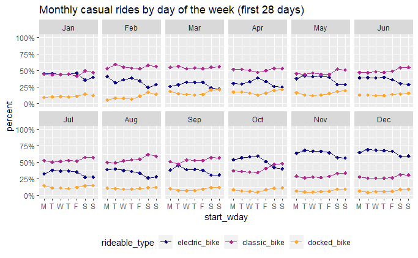

```r
bike_share %>%
  filter(member_casual == "casual" & start_mday < 29) %>%
  group_by(rideable_type, start_wday, start_month) %>%
  summarize(ride_count = n(), .groups = "keep") %>%
  group_by(start_wday, start_month) %>%
  mutate(percent = ride_count / sum(ride_count)) %>%
  ggplot(mapping = aes(x = start_wday, y = percent, group = rideable_type)) +
  geom_line(mapping = aes(color = rideable_type)) +
  geom_point(mapping = aes(color = rideable_type), size = 2, shape = 18) +
  scale_x_discrete(labels = substr(levels(bike_share$start_wday), 1, 1)) +
  scale_y_continuous(labels = scales::percent) +
  scale_color_viridis_d(option = "plasma", end = 0.8, drop = FALSE) +
  facet_wrap(~ start_month, nrow = 2) +
  coord_cartesian(ylim = c(0, 1)) +
  theme(legend.position = "bottom") +
  ggtitle(label = "Monthly casual rides by day of the week (first 28 days)")
```

For casual riders there’s a more significant decrease in the percentages of rides with electric bikes on the weekends, and corresponding increases in rides on classic and docked bikes. This trend even extends into the last three months of the year, when electric bike use was greater than that of the other bike types.

Let’s use similar plots to check whether the hour of the day has an effect on bike type.

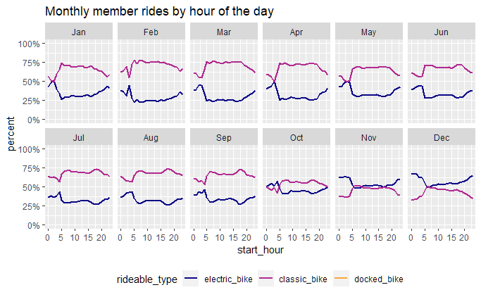

```r
bike_share %>%
  filter(member_casual == "member") %>%
  group_by(rideable_type, start_hour, start_month) %>%
  summarize(ride_count = n(), .groups = "keep") %>%
  group_by(start_hour, start_month) %>%
  mutate(percent = ride_count / sum(ride_count)) %>%
  ggplot(mapping = aes(x = start_hour, y = percent, group = rideable_type)) +
  geom_line(mapping = aes(color = rideable_type), size = 1) +
  scale_y_continuous(labels = scales::percent) +
  scale_color_viridis_d(option = "plasma", end = 0.8, drop = FALSE) +
  facet_wrap(~ start_month, nrow = 2) +
  coord_cartesian(ylim = c(0, 1)) +
  theme(legend.position = "bottom") +
  ggtitle(label = "Monthly member rides by hour of the day")
```

For members the use of electric bikes increases in the late evening and early morning hours. The relative proportions of bike types are stable in the other parts of the day.

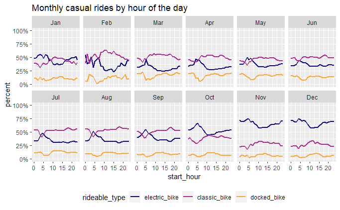

```r
bike_share %>%
  filter(member_casual == "casual") %>%
  group_by(rideable_type, start_hour, start_month) %>%
  summarize(ride_count = n(), .groups = "keep") %>%
  group_by(start_hour, start_month) %>%
  mutate(percent = ride_count / sum(ride_count)) %>%
  ggplot(mapping = aes(x = start_hour, y = percent, group = rideable_type)) +
  geom_line(mapping = aes(color = rideable_type), size = 1) +
  scale_y_continuous(labels = scales::percent) +
  scale_color_viridis_d(option = "plasma", end = 0.8, drop = FALSE) +
  facet_wrap(~ start_month, nrow = 2) +
  coord_cartesian(ylim = c(0, 1)) +
  theme(legend.position = "bottom") +
  ggtitle(label = "Monthly casual rides by hour of the day")
```

For casual riders, there’s more variability in choice of bike type throughout the day. If we focus on the high volume months May through September, we see a that electric bike use percentage is highest in the hours from 3 a.m. to 9 a.m., and levels out for the rest of the day. Classic bike use percentage dips during that period, and is fairly level the rest of the day except for a slight peak around 5 or 6 p.m. Docked bike use percentage is elevated in the period 10 a.m. to 3 p.m., and lowered in the period 4 a.m. to 7 a.m.

The patterns change in the last three months of the year, when hourly use percentages of electric and classic bikes are changing from month to month.

Let’s look at use for both hour of the day and day of the week, by quarters. We’ll look at each bike type separately.

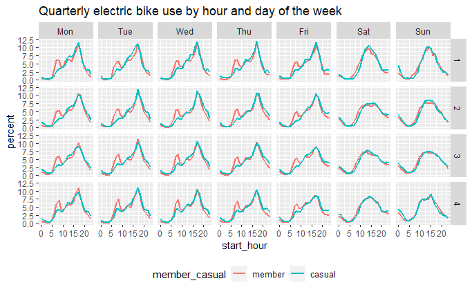

```r
 bike_share %>%
  filter(rideable_type == "electric_bike") %>%
  group_by(start_quarter, start_wday, start_hour, member_casual) %>%
  summarize(n = n(), .groups = "keep") %>%
  group_by(start_quarter, start_wday, member_casual) %>%
  mutate(percent = 100 * n / sum(n)) %>%
  ggplot(mapping = aes(x = start_hour, y = percent)) +
  geom_line(mapping = aes(color = member_casual), size = 1) +
  facet_grid(start_quarter ~ start_wday) +
  theme(legend.position = "bottom") +
  ggtitle(label = "Quarterly electric bike use by hour and day of the week")
```

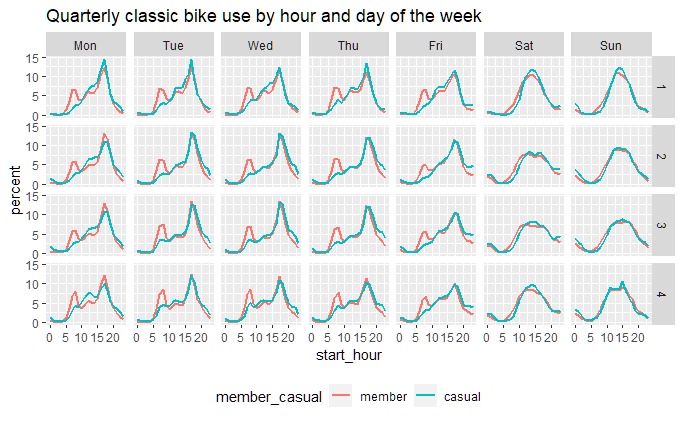

```r
 bike_share %>%
  filter(rideable_type == "classic_bike") %>%
  group_by(start_quarter, start_wday, start_hour, member_casual) %>%
  summarize(n = n(), .groups = "keep") %>%
  group_by(start_quarter, start_wday, member_casual) %>%
  mutate(percent = 100 * n / sum(n)) %>%
  ggplot(mapping = aes(x = start_hour, y = percent)) +
  geom_line(mapping = aes(color = member_casual), size = 1) +
  facet_grid(start_quarter ~ start_wday) +
  theme(legend.position = "bottom") +
  ggtitle(label = "Quarterly classic bike use by hour and day of the week")
```

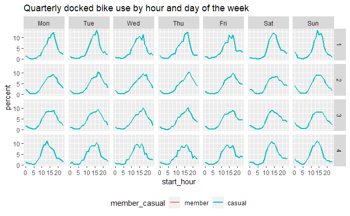

```r
 bike_share %>%
  filter(rideable_type == "docked_bike" & member_casual == "casual") %>%
  group_by(start_quarter, start_wday, start_hour, member_casual) %>%
  summarize(n = n(), .groups = "keep") %>%
  group_by(start_quarter, start_wday, member_casual) %>%
  mutate(percent = 100 * n / sum(n)) %>%
  ggplot(mapping = aes(x = start_hour, y = percent)) +
  geom_line(mapping = aes(color = member_casual), size = 1) +
  scale_color_discrete(drop = FALSE) +
  facet_grid(start_quarter ~ start_wday) +
  theme(legend.position = "bottom") +
  ggtitle(label = "Quarterly docked bike use by hour and day of the week")
```

The plots for electric and classic bikes resemble the plot we saw previously for overall bike use by week day and hour. The distributions for docked bikes on weekdays have peaks that are less narrow and sharp than those for electric and casual bikes on weekdays.

# Analysis - Ride duration

Let’s look at density plots of ride duration for each user type. We’ll limit the x-axis to 90 minutes or less.

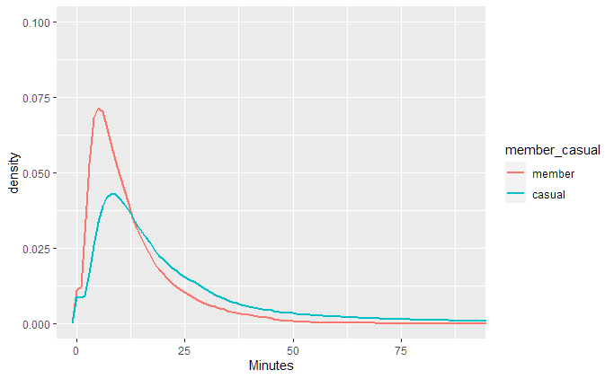

```r
bike_share %>%
  ggplot(mapping = aes(
                     x = ride_duration / 60,
                     y = after_stat(density),
                     group = member_casual,
                     color = member_casual
                   )
  ) +
  geom_freqpoly(binwidth = 1, size = 1) +
  xlab("Minutes") +
  coord_cartesian(xlim = c(0, 90), ylim = c(0, 0.1))
```

It’s clear that there’s a difference in ride duration between the two groups.

Let’s see how the type of bike affects the median and mean ride duration for each group.

```r
bike_share %>%
  group_by(rideable_type, member_casual) %>%
  summarize(
    median_duration_min = round(median(ride_duration) / 60, 1),
    mean_duration_min = round(mean(ride_duration) / 60, 1),
    count = n(),
    .groups = "keep"
  )
```

| rideable_type | member_casual | median_duration_min | mean_duration_min | count |
| --- | --- | --- | --- | --- |
| electric_bike | member | 8.9 | 12.7 | 1081205 |
| electric_bike | casual | 13.2 | 19.8 | 949966 |
| classic_bike | member | 10.0 | 14.1 | 1984163 |
| classic_bike | casual | 16.1 | 28.9 | 1266578 |
| docked_bike | member | 2.6 | 2.6 | 1 |
| docked_bike | casual | 28.8 | 76.1 | 312179 |

```r
NA
```

Compared to members, casual riders have median ride times that are about 4 minutes longer on electric bikes and about 6 minutes longer on classic bikes.

Let’s plot the distributions of each type of user by bike type. Since there was only one ride by a member on a docked bike, we’ll remove it from the data for this analysis. We’ll limit the x-axis to 45 minutes or less to see more detail.

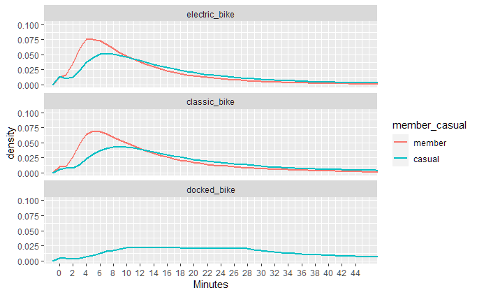

```r
bike_share %>%
  filter(rideable_type != "docked_bike" | member_casual != "member") %>%
  ggplot(mapping = aes(
                     x = ride_duration / 60,
                     y = after_stat(density),
                     group = member_casual,
                     color = member_casual
                   )
  ) +
  geom_freqpoly(binwidth = 1, size = 1) +
  scale_x_continuous(breaks = 0:22 * 2) +
  xlab("Minutes") +
  coord_cartesian(xlim = c(0, 45), ylim = c(0, 0.1)) +
  facet_wrap(~ rideable_type, nrow = 3)
```

The docked bikes have a very different distribution compared to electric and classic bikes. And we see the difference in ride times for members and casual rides on electric and classic bikes.

Let’s rearrange these plots to put all the bike types together for each type of user.

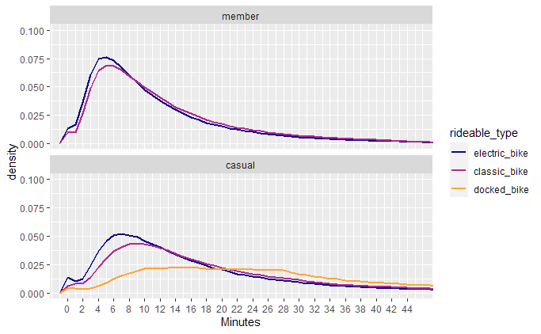

```r
bike_share %>%
  filter(rideable_type != "docked_bike" | member_casual != "member") %>%
  ggplot(mapping = aes(
                     x = ride_duration / 60,
                     y = after_stat(density),
                     group = rideable_type,
                     color = rideable_type
                   )
  ) +
  geom_freqpoly(binwidth = 1, size = 1) +
  scale_x_continuous(breaks = 0:22 * 2) +
  xlab("Minutes") +
  coord_cartesian(xlim = c(0, 45), ylim = c(0, 0.1)) +
  scale_color_viridis_d(option = "plasma", end = 0.8, drop = FALSE) +
  facet_wrap(~ member_casual, nrow = 2)
```

For members, the ride time distributions are nearly the same for electric and classic bikes. Let’s see whether that holds across quarters. First we’ll look at rides by members.

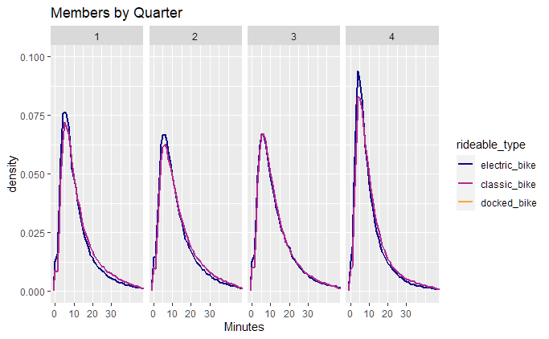

```r
bike_share %>%
  filter(rideable_type != "docked_bike" & member_casual == "member") %>%
  ggplot(mapping = aes(
                     x = ride_duration / 60,
                     y = after_stat(density),
                     group = rideable_type,
                     color = rideable_type
                   )
  ) +
  geom_freqpoly(binwidth = 1, size = 1) +
  xlab("Minutes") +
  scale_x_continuous(breaks = 0:3 * 10) +
  coord_cartesian(xlim = c(0, 45), ylim = c(0, 0.1)) +
  scale_color_viridis_d(option = "plasma", end = 0.8, drop = FALSE) +
  facet_wrap(~ start_quarter, nrow = 1) +
  ggtitle(label = "Members by Quarter")
```

The distributions for electric and classic bikes agree well in each quarter, particularly in the high volume second and third quarters. The peaks are higher in the colder months, indicating a decrease in ride times.

Now let’s look as the plots for casual riders.

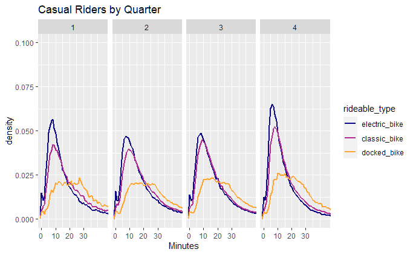

```r
bike_share %>%
  filter(member_casual == "casual") %>%
  ggplot(mapping = aes(
                     x = ride_duration / 60,
                     y = after_stat(density),
                     group = rideable_type,
                     color = rideable_type
                   )
  ) +
  geom_freqpoly(binwidth = 1, size = 1) +
  xlab("Minutes") +
  scale_x_continuous(breaks = 0:3 * 10) +
  coord_cartesian(xlim = c(0, 45), ylim = c(0, 0.1)) +
  scale_color_viridis_d(option = "plasma", end = 0.8, drop = FALSE) +
  facet_wrap(~ start_quarter, nrow = 1) +
  ggtitle(label = "Casual Riders by Quarter")
```

The distributions for electric and classic bikes don’t agree as well as they did for rides by members, but they’re very similar. The distributions for all three bike types look stable across quarters, with expected decreases in ride duration in the colder months.

Let’s see whether the day of the week has an effect on ride time distributions.

First we’ll look at ride times on electric bikes by members and by casual riders.

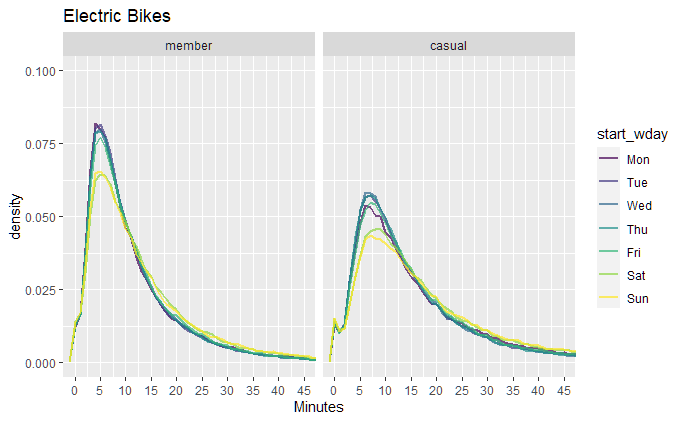

```r
bike_share %>%
  filter(rideable_type == "electric_bike") %>%
  ggplot(mapping = aes(
                     x = ride_duration / 60,
                     y = after_stat(density),
                     group = start_wday,
                     color = start_wday
                   )
  ) +
  geom_freqpoly(binwidth = 1, size = 1, alpha = 0.7) +
  scale_x_continuous(breaks = 0:9 * 5) +
  scale_color_ordinal() +
  xlab("Minutes") +
  coord_cartesian(xlim = c(0, 45), ylim = c(0, 0.1)) +
  facet_wrap(~ member_casual) +
  ggtitle(label = "Electric Bikes")
```

It looks like there are different distributions on weekdays and weekends. Let’s look at weekdays only.

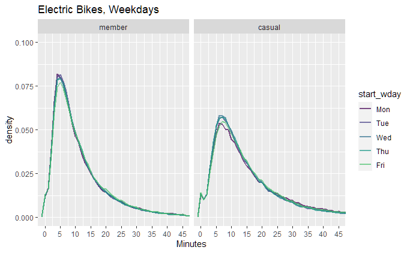

```r
bike_share %>%
  filter(rideable_type == "electric_bike") %>%
  filter(start_wday %in% levels(bike_share$start_wday)[1:5])  %>%
  ggplot(mapping = aes(
                     x = ride_duration / 60,
                     y = after_stat(density),
                     group = start_wday,
                     color = start_wday
                   )
  ) +
  geom_freqpoly(binwidth = 1, size = 1, alpha = 0.7) +
  scale_x_continuous(breaks = 0:9 * 5) +
  xlab("Minutes") +
  scale_color_ordinal(end = 5/7) +
  coord_cartesian(xlim = c(0, 45), ylim = c(0, 0.1)) +
  facet_wrap(~ member_casual) +
  ggtitle(label = "Electric Bikes, Weekdays")
```

Now let’s look at weekends.

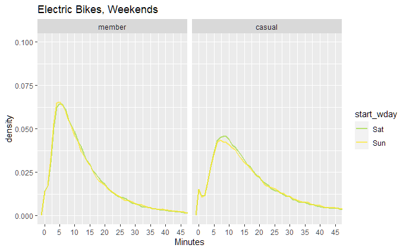

```r
bike_share %>%
  filter(rideable_type == "electric_bike") %>%
  filter(start_wday %in% levels(bike_share$start_wday)[6:7])  %>%
  ggplot(mapping = aes(
                     x = ride_duration / 60,
                     y = after_stat(density),
                     group = start_wday,
                     color = start_wday
                   )
  ) +
  geom_freqpoly(binwidth = 1, size = 1, alpha = 0.7) +
  scale_x_continuous(breaks = 0:9 * 5) +
  xlab("Minutes") +
  scale_color_ordinal(begin = 6/7) +
  coord_cartesian(xlim = c(0, 45), ylim = c(0, 0.1)) +
  facet_wrap(~ member_casual) +
  ggtitle(label = "Electric Bikes, Weekends")
```

Let’s check whether these patterns hold across quarters.

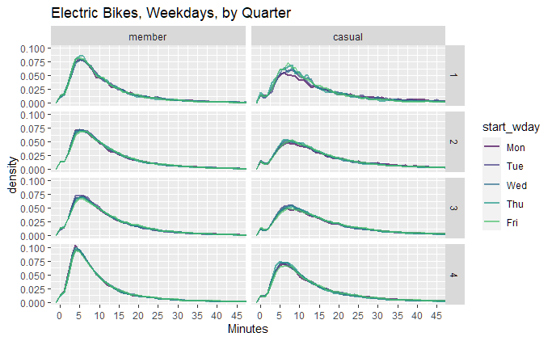

```r
bike_share %>%
  filter(rideable_type == "electric_bike") %>%
  filter(start_wday %in% levels(bike_share$start_wday)[1:5])  %>%
  ggplot(mapping = aes(
                     x = ride_duration / 60,
                     y = after_stat(density),
                     group = start_wday,
                     color = start_wday
                   )
  ) +
  geom_freqpoly(binwidth = 1, size = 1, alpha = 0.7) +
  scale_x_continuous(breaks = 0:9 * 5) +
  xlab("Minutes") +
  scale_color_ordinal(end = 5/7) +
  coord_cartesian(xlim = c(0, 45), ylim = c(0, 0.1)) +
  facet_grid(start_quarter ~ member_casual) +
  ggtitle(label = "Electric Bikes, Weekdays, by Quarter")
```

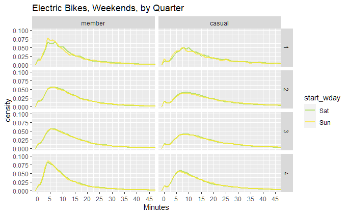

```r
bike_share %>%
  filter(rideable_type == "electric_bike") %>%
  filter(start_wday %in% levels(bike_share$start_wday)[6:7])  %>%
  ggplot(mapping = aes(
                     x = ride_duration / 60,
                     y = after_stat(density),
                     group = start_wday,
                     color = start_wday
                   )
  ) +
  geom_freqpoly(binwidth = 1, size = 1, alpha = 0.7) +
  scale_x_continuous(breaks = 0:9 * 5) +
  xlab("Minutes") +
  scale_color_ordinal(begin = 6/7) +
  coord_cartesian(xlim = c(0, 45), ylim = c(0, 0.1)) +
  facet_grid(start_quarter ~ member_casual) +
  ggtitle(label = "Electric Bikes, Weekends, by Quarter")
```

For electric bikes there are different ride time distributions for weekdays and weekends.

Let’s check the same for classic bikes.

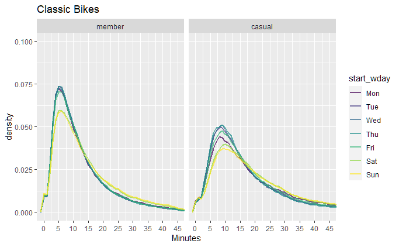

```r
bike_share %>%
  filter(rideable_type == "classic_bike") %>%
  ggplot(mapping = aes(
                     x = ride_duration / 60,
                     y = after_stat(density),
                     group = start_wday,
                     color = start_wday
                   )
  ) +
  geom_freqpoly(binwidth = 1, size = 1, alpha = 0.7) +
  scale_x_continuous(breaks = 0:9 * 5) +
  scale_color_ordinal() +
  xlab("Minutes") +
  coord_cartesian(xlim = c(0, 45), ylim = c(0, 0.1)) +
  facet_wrap(~ member_casual) +
  ggtitle(label = "Classic Bikes")
```

For classic bikes there’s also a difference in ride duration on the weekends for both members and casual riders.

Let’s look at weekdays only.

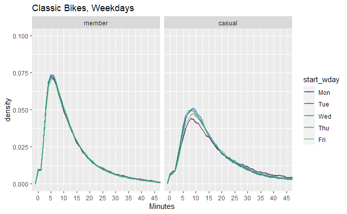

```r
bike_share %>%
  filter(rideable_type == "classic_bike") %>%
  filter(start_wday %in% levels(bike_share$start_wday)[1:5])  %>%
  ggplot(mapping = aes(
                     x = ride_duration / 60,
                     y = after_stat(density),
                     group = start_wday,
                     color = start_wday
                   )
  ) +
  geom_freqpoly(binwidth = 1, size = 1, alpha = 0.7) +
  scale_x_continuous(breaks = 0:9 * 5) +
  xlab("Minutes") +
  scale_color_ordinal(end = 5/7) +
  coord_cartesian(xlim = c(0, 45), ylim = c(0, 0.1)) +
  facet_wrap(~ member_casual) +
  ggtitle(label = "Classic Bikes, Weekdays")
```

And let’s look at weekends.

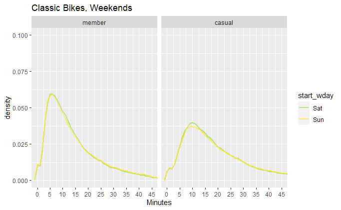

```r
bike_share %>%
  filter(rideable_type == "classic_bike") %>%
  filter(start_wday %in% levels(bike_share$start_wday)[6:7])  %>%
  ggplot(mapping = aes(
                     x = ride_duration / 60,
                     y = after_stat(density),
                     group = start_wday,
                     color = start_wday
                   )
  ) +
  geom_freqpoly(binwidth = 1, size = 1, alpha = 0.7) +
  scale_x_continuous(breaks = 0:9 * 5) +
  xlab("Minutes") +
  scale_color_ordinal(begin = 6/7) +
  coord_cartesian(xlim = c(0, 45), ylim = c(0, 0.1)) +
  facet_wrap(~ member_casual) +
  ggtitle(label = "Classic Bikes, Weekends")
```

Let’s check whether these patterns hold across quarters.

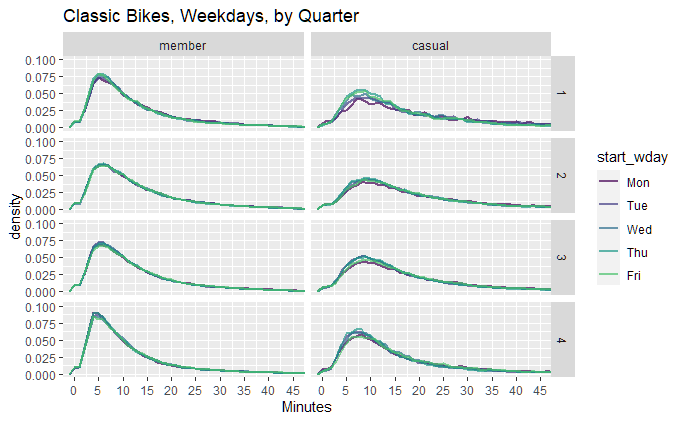

```r
bike_share %>%
  filter(rideable_type == "classic_bike") %>%
  filter(start_wday %in% levels(bike_share$start_wday)[1:5])  %>%
  ggplot(mapping = aes(
                     x = ride_duration / 60,
                     y = after_stat(density),
                     group = start_wday,
                     color = start_wday
                   )
  ) +
  geom_freqpoly(binwidth = 1, size = 1, alpha = 0.7) +
    scale_x_continuous(breaks = 0:9 * 5) +
  xlab("Minutes") +
  scale_color_ordinal(end = 5/7) +
  coord_cartesian(xlim = c(0, 45), ylim = c(0, 0.1)) +
  facet_grid(start_quarter ~ member_casual) +
  ggtitle(label = "Classic Bikes, Weekdays, by Quarter")
```

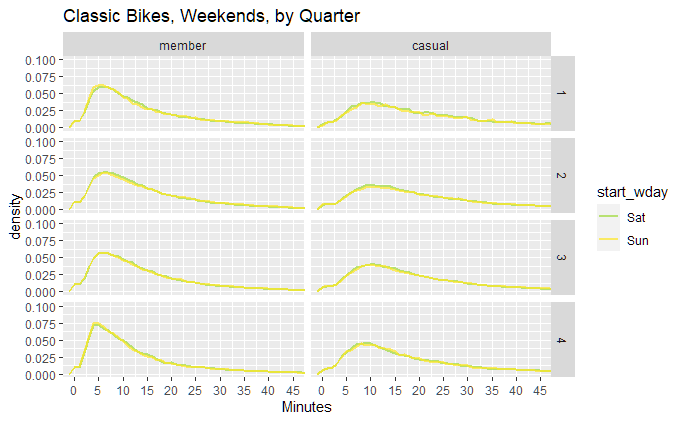

```r
bike_share %>%
  filter(rideable_type == "classic_bike") %>%
  filter(start_wday %in% levels(bike_share$start_wday)[6:7])  %>%
  ggplot(mapping = aes(
                     x = ride_duration / 60,
                     y = after_stat(density),
                     group = start_wday,
                     color = start_wday
                   )
  ) +
  geom_freqpoly(binwidth = 1, size = 1, alpha = 0.7) +
  scale_x_continuous(breaks = 0:9 * 5) +
  xlab("Minutes") +
  scale_color_ordinal(begin = 6/7) +
  coord_cartesian(xlim = c(0, 45), ylim = c(0, 0.1)) +
  facet_grid(start_quarter ~ member_casual) +
  ggtitle(label = "Classic Bikes, Weekends, by Quarter")
```

Now let’s look at the distributions by day of the week for docked bikes.

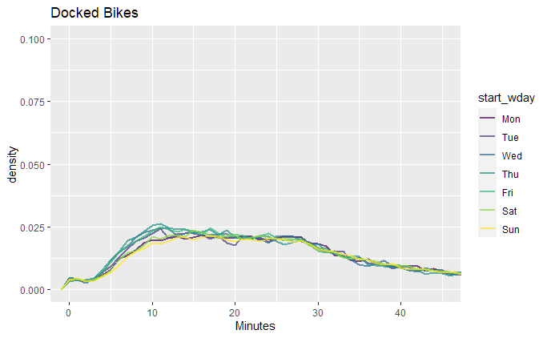

```r
bike_share %>%
  filter(rideable_type == "docked_bike") %>%
  ggplot(mapping = aes(
                     x = ride_duration / 60,
                     y = after_stat(density),
                     group = start_wday,
                     color = start_wday
                   )
  ) +
  geom_freqpoly(binwidth = 1, size = 1, alpha = 0.7) +
  scale_x_continuous(breaks = 0:9 * 10) +
  xlab("Minutes") +
  coord_cartesian(xlim = c(0, 45), ylim = c(0, 0.1)) +
  ggtitle(label = "Docked Bikes")
```

The rides on docked bikes don’t appear to have significantly different ride time distributions for weekdays and weekends. Let’s graph them by quarter to be sure.

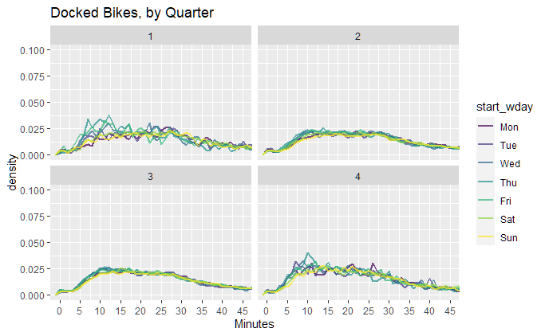

```r
bike_share %>%
  filter(rideable_type == "docked_bike") %>%
  ggplot(mapping = aes(
                     x = ride_duration / 60,
                     y = after_stat(density),
                     group = start_wday,
                     color = start_wday
                   )
  ) +
  geom_freqpoly(binwidth = 1, size = 1, alpha = 0.7) +
  scale_x_continuous(breaks = 0:9 * 5) +
  xlab("Minutes") +
  coord_cartesian(xlim = c(0, 45), ylim = c(0, 0.1)) +
  facet_wrap(~ start_quarter) +
  ggtitle(label = "Docked Bikes, by Quarter")
```

There isn’t a clear distinction in ride duration between weekdays and weekends for docked bikes.

But because of the distinction for electric and classic bikes, we’ll add a column to the data set to classify each day as a weekday or a weekend. This will simplify the analysis for those bike types.

```r
bike_share <- bike_share %>%
  mutate(wkend = factor(
                   ifelse(start_wday %in% c("Sat", "Sun"), "Weekend", "Weekday")
                 )
  )
```

Let’s look at density plots of ride duration for all bike types on weekdays and weekends.

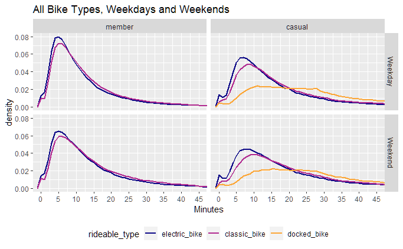

```r
bike_share %>%
  filter(rideable_type != "docked_bike" | member_casual != "member") %>%
  ggplot(mapping = aes(
                     x = ride_duration / 60,
                     y = after_stat(density),
                     group = rideable_type,
                     color = rideable_type
                   )
  ) +
  geom_freqpoly(binwidth = 1, size = 1) +
  scale_x_continuous(breaks = 0:9 * 5) +
  xlab("Minutes") +
  scale_color_viridis_d(option = "plasma", end = 0.8, drop = FALSE) +
  coord_cartesian(xlim = c(0, 45), ylim = c(0, 0.08)) +
  facet_grid(wkend ~ member_casual) +
  theme(legend.position = "bottom") +
  ggtitle(label = "All Bike Types, Weekdays and Weekends")
```

In these plots we see that rides by casual riders tend to be longer on weekdays and weekends than rides by members. We also see that bike type has a greater impact on the ride time distribution for casual riders than it does for members.

Let’s look at the medians, first quartiles, third quartiles, and interquartile ranges of ride durations for each user group and bike type. We’ll also treat weekdays and weekends separately, and we’ll get values for each quarter of the year.

First we’ll look at electric bikes. We’ll make boxplots of ride duration. The line inside each box represents the median of ride duration, while the bottoms and tops of each box represent the 25th and 75th percentiles of ride duration, respectively.

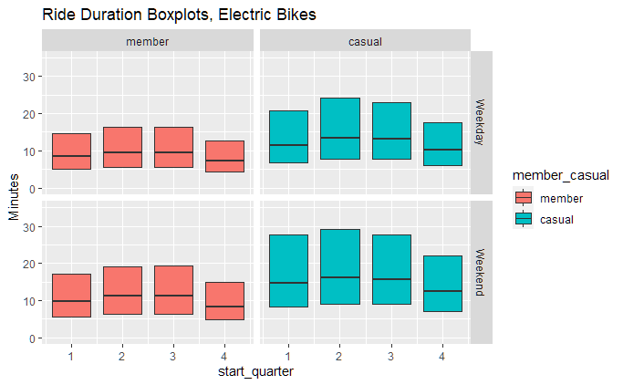

```r
bike_share %>%
  filter(rideable_type == "electric_bike") %>%
  ggplot(mapping = aes(x = start_quarter, y = ride_duration / 60) ) +
  geom_boxplot(
    mapping = aes(group = start_quarter, fill = member_casual),
    position = "dodge",
    outlier.shape = NA,
    coef = 0,
  ) +
  ylab("Minutes") +
  coord_cartesian(ylim = c(0, 35)) +
  facet_grid(wkend ~ member_casual) +
  ggtitle(label = "Ride Duration Boxplots, Electric Bikes")
```

We see that for electric bikes the median ride times are slightly decreased in the first and fourth quarters, probably due to colder weather. We also see that rides by casual riders are generally longer than rides by members.

Rides by casual riders also have a larger interquartile range (IQR), which is the difference between the 75th percentile and the 25th percentile of ride duration, as seen by the greater heights of the boxes for casual riders.

On both weekdays and weekends, and in all quarters of the year, rides by casual riders have higher medians, 25th percentiles, and 75th percentiles than do the rides by members.

Also, the distributions are fairly stable across the year except for expected decreases in ride duration in the colder months.

Let’s look at the same for classic bikes.

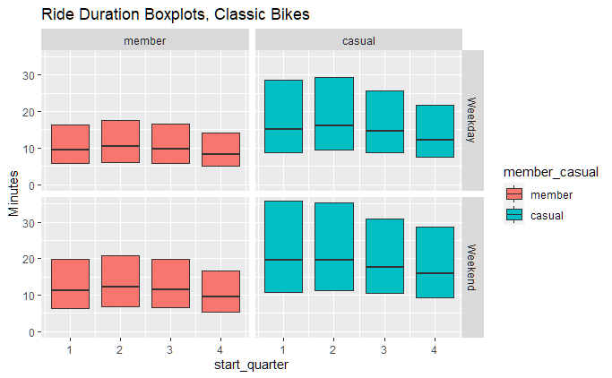

```r
bike_share %>%
  filter(rideable_type == "classic_bike") %>%
  ggplot(mapping = aes(x = start_quarter, y = ride_duration / 60) ) +
  geom_boxplot(
    mapping = aes(group = start_quarter, fill = member_casual),
    position = "dodge",
    outlier.shape = NA,
    coef = 0,
  ) +
  ylab("Minutes") +
  coord_cartesian(ylim = c(0, 35)) +
  facet_grid(wkend ~ member_casual) +
  ggtitle(label = "Ride Duration Boxplots, Classic Bikes")
```

The plots for classic bikes show the same contrasts between members and casual riders that were seen in the plots for electric bikes. But for the classic bikes there’s a significant upward shift in median and IQR for the casual riders.

Now let’s look at box plots for docked bikes. We’ll need to use a different scale for the y-axis since these rides last longer.

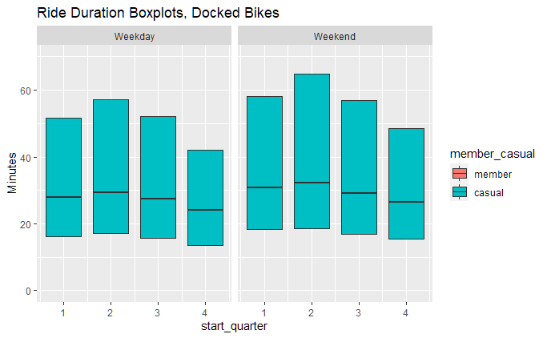

```r
bike_share %>%
  filter(rideable_type == "docked_bike" & member_casual == "casual") %>%
  ggplot(mapping = aes(x = start_quarter, y = ride_duration / 60) ) +
  geom_boxplot(
    mapping = aes(group = start_quarter, fill = member_casual),
    position = "dodge",
    outlier.shape = NA,
    coef = 0,
  ) +
  ylab("Minutes") +
  scale_fill_discrete(drop = FALSE) +
  coord_cartesian(ylim = c(0, 70)) +
  facet_wrap(~ wkend) +
  ggtitle(label = "Ride Duration Boxplots, Docked Bikes")
```

The stats for these rides also look stable over the quarters of the year.

Let’s summarize the data on median ride duration with a bar plot.

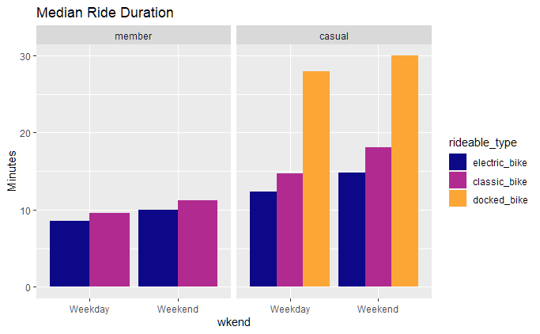

```r
bike_share %>%
  filter(rideable_type != "docked_bike" | member_casual != "member") %>%
  group_by(wkend, rideable_type, member_casual) %>%
  summarize(median = median(ride_duration) / 60 , .groups = "keep") %>%
  ggplot(mapping = aes(x = wkend, y = median)) +
  geom_col(mapping = aes(fill = rideable_type), position = "dodge") +
  ylab("Minutes") +
  scale_fill_viridis_d(option = "plasma", end = 0.8, drop = FALSE) +
  facet_wrap(~ member_casual) +
  ggtitle(label = "Median Ride Duration")
```

And let’s also summarize the stats in a box plot.

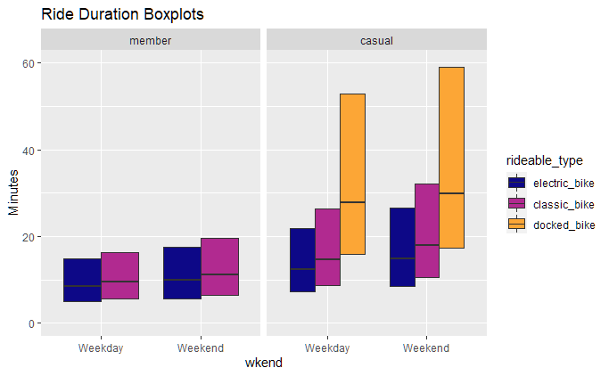

```r
bike_share %>%
  filter(rideable_type != "docked_bike" | member_casual != "member") %>%
  ggplot(mapping = aes(x = wkend, y = ride_duration / 60)) +
  geom_boxplot(
    mapping = aes(fill = rideable_type),
    position = "dodge",
    outlier.shape = NA,
    coef = 0,
  ) +
  ylab("Minutes") +
  scale_fill_viridis_d(option = "plasma", end = 0.8, drop = FALSE) +
  coord_cartesian(ylim = c(0, 60)) +
  facet_wrap(~ member_casual) +
  ggtitle(label = "Ride Duration Boxplots")
```

While these differences in medians or IQR may seem small, they represent significant differences in behavior among the two user groups. For example, the cumulative distribution function below shows, for x number of minutes on the x-axis, the percentage of rides that last x minutes or less. For rides on classic bikes on weekends, about 65% of rides by members are 15 minutes or less, but only 40% of rides by casual riders are 15 minutes or less.

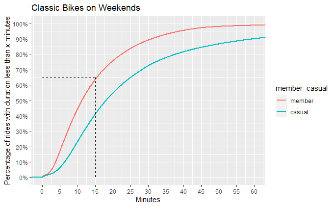

```r
bike_share %>%
  filter(rideable_type == "classic_bike" & wkend == "Weekend") %>%
  ggplot(mapping = aes(x = ride_duration / 60,  group = member_casual)) +
  stat_ecdf(mapping = aes(color = member_casual), size = 1) +
  geom_segment(
    mapping = aes(x = 0, y = 0.65, xend = 15, yend = 0.65),
    linetype = 2
  ) +
  geom_segment(
    mapping = aes(x = 0, y = 0.40, xend = 15, yend = 0.40),
    linetype = 2
  ) +
  geom_segment(
    mapping = aes(x = 15, y = 0, xend = 15, yend = 0.65),
    linetype  = 2
  ) +
  scale_x_continuous(breaks = 0:12 * 5) +
  scale_y_continuous(breaks = 0:10 / 10, labels = scales::percent) +
  coord_cartesian(xlim = c(0, 60)) +
  xlab("Minutes") +
  ylab("Percentage of rides with duration less than x minutes") +
  ggtitle("Classic Bikes on Weekends")
```

Let’s plot cumulative distribution functions for each bike type and for weekdays and weekends.

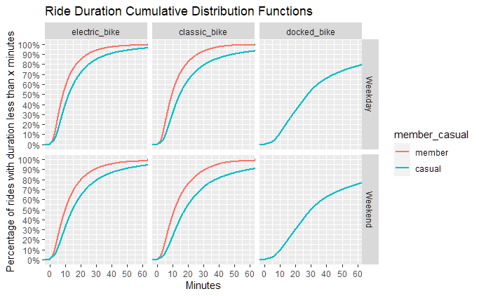

```r
bike_share %>%
  filter(rideable_type != "docked_bike" | member_casual != "member") %>%
  ggplot(mapping = aes(x = ride_duration / 60,  group = member_casual)) +
  stat_ecdf(mapping = aes(color = member_casual), size = 1) +
  scale_x_continuous(breaks = 0:6 * 10) +
  scale_y_continuous(breaks = 0:10 / 10, labels = scales::percent) +
  coord_cartesian(xlim = c(0, 60)) +
  xlab("Minutes") +
  ylab("Percentage of rides with duration less than x minutes") +
  facet_grid(wkend ~ rideable_type) +
  ggtitle("Ride Duration Cumulative Distribution Functions")
```

Let’s also put all bike types in one plot for each user group, and for weekdays and weekends.

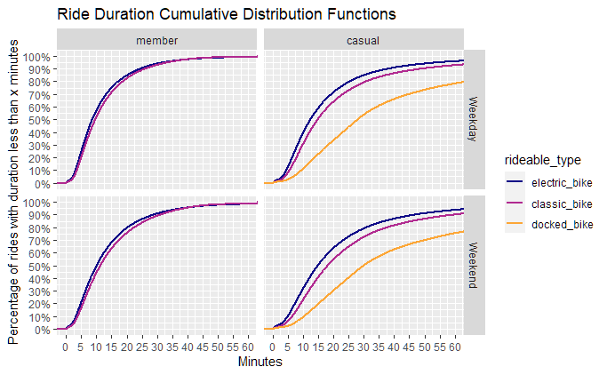

```r
bike_share %>%
  filter(rideable_type != "docked_bike" | member_casual != "member") %>%
  ggplot(mapping = aes(x = ride_duration / 60,  group = rideable_type)) +
  stat_ecdf(mapping = aes(color = rideable_type), size = 1) +
  scale_x_continuous(breaks = 0:12 * 5) +
  scale_y_continuous(breaks = 0:10 / 10, labels = scales::percent) +
  coord_cartesian(xlim = c(0, 60)) +
  xlab("Minutes") +
  ylab("Percentage of rides with duration less than x minutes") +
  scale_color_viridis_d(option = "plasma", end = 0.8, drop = FALSE) +
  facet_grid(wkend ~ member_casual) +
  ggtitle("Ride Duration Cumulative Distribution Functions")
```

And we’ll plot the overall cumulative distributions for weekdays and for weekends.

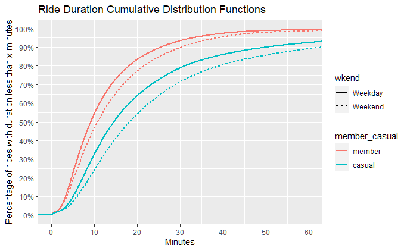

```r
bike_share %>%
  ggplot(mapping = aes(
                     x = ride_duration / 60,
                     group = interaction(member_casual, wkend)
                   )
  ) +
  stat_ecdf(mapping = aes(color = member_casual, linetype = wkend), size = 1) +
  scale_x_continuous(breaks = 0:6 * 10) +
  scale_y_continuous(breaks = 0:10 / 10, labels = scales::percent) +
  coord_cartesian(xlim = c(0, 60)) +
  xlab("Minutes") +
  ylab("Percentage of rides with duration less than x minutes") +
  ggtitle("Ride Duration Cumulative Distribution Functions")
```

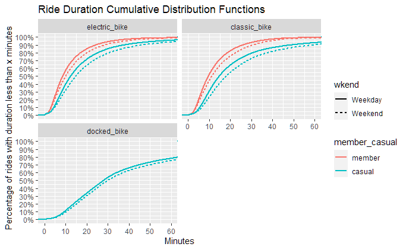

```r
bike_share %>%
  filter(rideable_type != "docked_bike" | member_casual != "member") %>%
  ggplot(mapping = aes(
                     x = ride_duration / 60,
                     group = interaction(member_casual, wkend)
                   )
  ) +
  stat_ecdf(mapping = aes(color = member_casual, linetype = wkend), size = 1) +
  scale_x_continuous(breaks = 0:6 * 10) +
  scale_y_continuous(breaks = 0:10 / 10, labels = scales::percent) +
  coord_cartesian(xlim = c(0, 60)) +
  xlab("Minutes") +
  ylab("Percentage of rides with duration less than x minutes") +
  facet_wrap(~ rideable_type, nrow = 2) +
  ggtitle("Ride Duration Cumulative Distribution Functions")
```

Now let’s look at how ride durations vary by hour of the day. We’ll start by looking at density plots for each hour. We’ll limit the x-axis to 45 minutes or less.

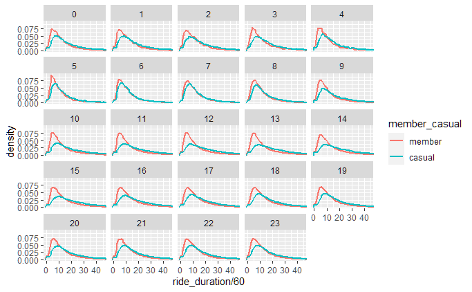

```r
bike_share %>%
  ggplot(mapping = aes(
                     x = ride_duration / 60,
                     y = after_stat(density),
                     group = member_casual,
                     color = member_casual
                   )
  ) +
  geom_freqpoly(binwidth = 1, size = 1) +
  facet_wrap(~ start_hour) +
  coord_cartesian(xlim = c(0, 45))
```

For most hours of the day the ride duration distributions are similar to the overall distributions for members and casual riders. But during the hours 6 to 8 a.m. the distributions for the two user groups are very close. Presumably this represents users going to work in the morning, so we wouldn’t expect longer rides at this period in the day. Also, we’ve already seen that the numbers of rides by casual riders are low at that time of day, at least on weekdays.

Let’s look at boxplots of ride duration for each hour, divided into weekdays and weekends.

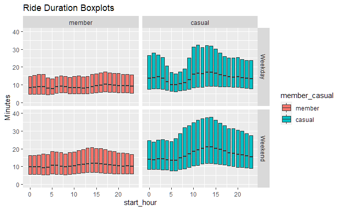

```r
bike_share %>%
  ggplot(mapping = aes(x = start_hour, y = ride_duration / 60) ) +
  geom_boxplot(
    mapping = aes(group = start_hour, fill = member_casual),
    position = "dodge",
    outlier.shape = NA,
    coef = 0,
  ) +
  ylab("Minutes") +
  facet_grid(wkend ~ member_casual) +
  coord_cartesian(ylim = c(0, 40)) +
  ggtitle(label = "Ride Duration Boxplots")
```

For members there isn’t a lot of variation in ride duration during the course of the day on weekdays or weekends. For casual riders, median ride duration and IQR are lowest around 4 to 7 a.m. and peak around 10 a.m. to 3 p.m.

Let’s check whether bike type has an affect on these patterns.

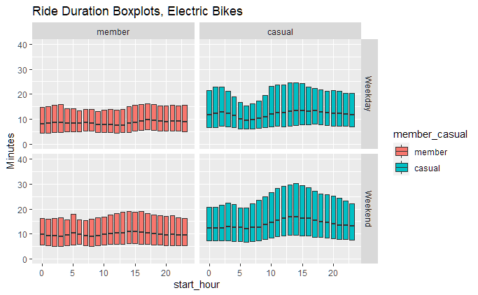

```r
bike_share %>%
  filter(rideable_type == "electric_bike") %>%
  ggplot(mapping = aes(x = start_hour, y = ride_duration / 60) ) +
  geom_boxplot(
    mapping = aes(group = start_hour, fill = member_casual),
    position = "dodge",
    outlier.shape = NA,
    coef = 0,
  ) +
  ylab("Minutes") +
  facet_grid(wkend ~ member_casual) +
  coord_cartesian(ylim = c(0, 40)) +
  ggtitle(label = "Ride Duration Boxplots, Electric Bikes")
```

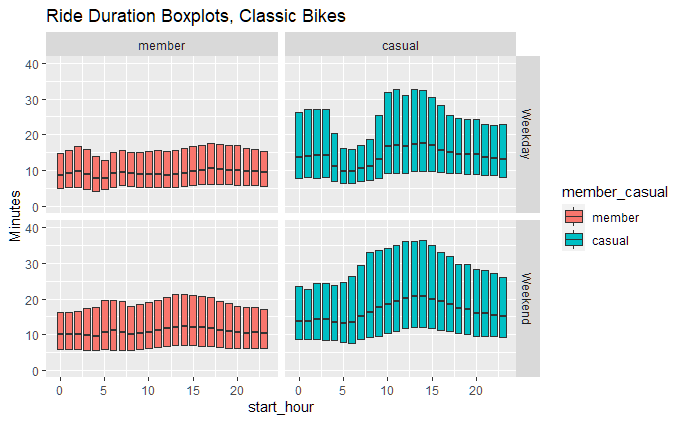

```r
bike_share %>%
  filter(rideable_type == "classic_bike") %>%
  ggplot(mapping = aes(x = start_hour, y = ride_duration / 60) ) +
  geom_boxplot(
    mapping = aes(group = start_hour, fill = member_casual),
    position = "dodge",
    outlier.shape = NA,
    coef = 0,
  ) +
  ylab("Minutes") +
  facet_grid(wkend ~ member_casual) +
  coord_cartesian(ylim = c(0, 40)) +
  ggtitle(label = "Ride Duration Boxplots, Classic Bikes")
```

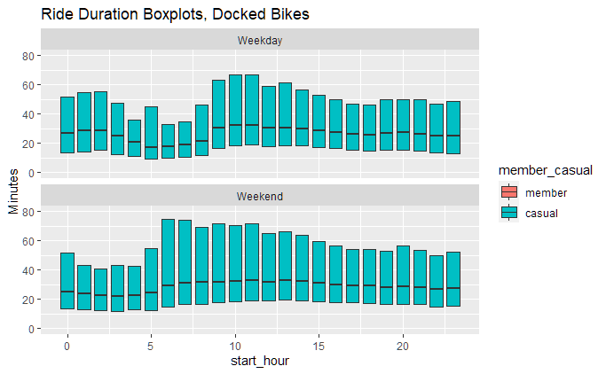

```r
bike_share %>%
  filter(rideable_type == "docked_bike" & member_casual == "casual") %>%
  ggplot(mapping = aes(x = start_hour, y = ride_duration / 60) ) +
  geom_boxplot(
    mapping = aes(group = start_hour, fill = member_casual),
    position = "dodge",
    outlier.shape = NA,
    coef = 0,
  ) +
  ylab("Minutes") +
  scale_fill_discrete(drop = FALSE) +
  facet_wrap(~ wkend, nrow= 2) +
  coord_cartesian(ylim = c(0, 80)) +
  ggtitle(label = "Ride Duration Boxplots, Docked Bikes")
```

The general pattern stays the same for electric and classic bikes. There’s more variation in rides duration during the day for docked bikes, but they represent only about 12% of rides by casual riders.

Let’s check whether there’s an seasonal variation in ride duration by hour of the day. We’ll look at rides by quarter on weekdays and on weekends.

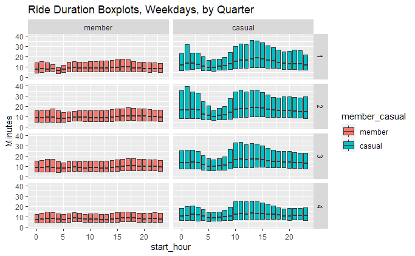

```r
bike_share %>%
  filter(wkend == "Weekday") %>%
  ggplot(mapping = aes(x = start_hour, y = ride_duration / 60) ) +
  geom_boxplot(
    mapping = aes(group = start_hour, fill = member_casual),
    position = "dodge",
    outlier.shape = NA,
    coef = 0,
  ) +
  ylab("Minutes") +
  facet_grid(start_quarter ~ member_casual) +
  coord_cartesian(ylim = c(0, 40)) +
  ggtitle(label = "Ride Duration Boxplots, Weekdays, by Quarter")
```

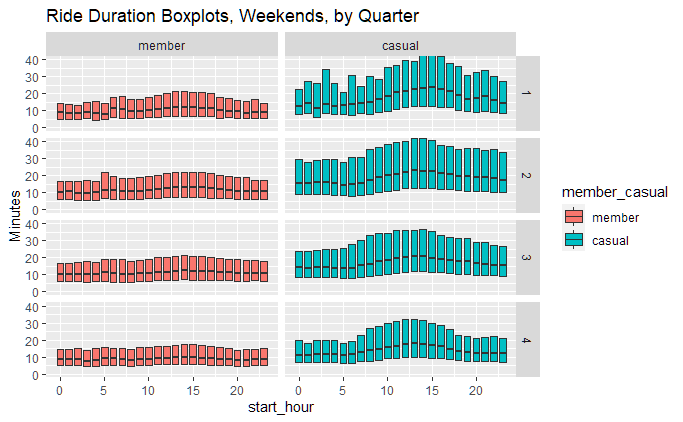

```r
bike_share %>%
  filter(wkend == "Weekend") %>%
  ggplot(mapping = aes(x = start_hour, y = ride_duration / 60) ) +
  geom_boxplot(
    mapping = aes(group = start_hour, fill = member_casual),
    position = "dodge",
    outlier.shape = NA,
    coef = 0,
  ) +
  ylab("Minutes") +
  facet_grid(start_quarter ~ member_casual) +
  coord_cartesian(ylim = c(0, 40)) +
  ggtitle(label = "Ride Duration Boxplots, Weekends, by Quarter")
```

The patterns don’t change much based on the time of the year.

Let’s plot the median ride durations for each rider group by hour of the day.

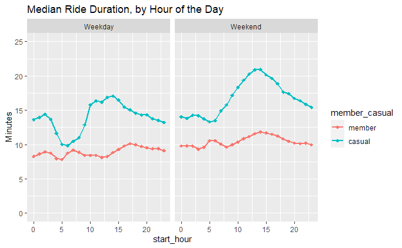

```r
bike_share %>%
  group_by(start_hour, member_casual, wkend) %>%
  summarize(median = median(ride_duration) / 60, .groups = "keep") %>%
  ggplot(mapping = aes(x = start_hour, y = median, group = member_casual)) +
  geom_line(mapping = aes(color = member_casual), size = 1) +
  geom_point(mapping = aes(color = member_casual), size = 2, shape = 18) +
  ylab("Minutes") +
  coord_cartesian(ylim = c(0, 25)) +
  facet_wrap(~ wkend) +
  ggtitle(label = "Median Ride Duration, by Hour of the Day")
```

The median ride duration for casual riders has a lot of variation, depending on the time of day, and on whether it’s a weekday or weekend. For members, the median ride duration is fairly constant through the hours of the day, and only slightly elevated on weekends.

# Analysis - Location Data

We’ll start by adding two columns, lat and lng, to the data set, using ride start latitude and longitude, rounded to two decimal places.

```r
bike_share <- bike_share %>%
  mutate(
    lat = round(start_lat, 2),
    lng = round(start_lng, 2)
  )
```

Now we’ll look at the geographic distributions of ride start locations for members and for casual riders.

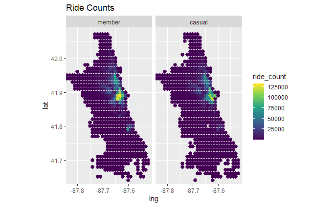

```r
bike_share %>%
  group_by(lat, lng, member_casual) %>%
  summarize(ride_count = n(), .groups = "keep") %>%
  ggplot(mapping = aes(x = lng, y = lat)) +
  geom_point(mapping = aes(color = ride_count), size = 2.5) +
  scale_color_viridis_c() +
  bike_coord +
  facet_wrap(~ member_casual) +
  ggtitle(label = "Ride Counts")
```

There isn’t much difference in where the rides begin, keeping in mind that the overall ratio of rides by members to rides by casual riders is about 6 to 5.

Let’s see whether there are any quarters in which there’s a difference in ride locations. We’ll look at both weekdays and weekends.

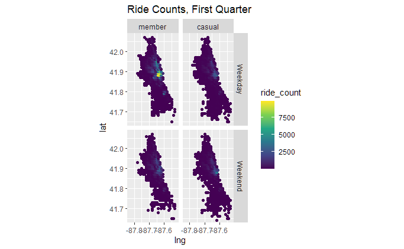

```r
bike_share %>%
  filter(start_quarter == 1) %>%
  group_by(lat, lng, member_casual, wkend) %>%
  summarize(ride_count = n(), .groups = "keep") %>%
  ggplot(mapping = aes(x = lng, y = lat)) +
  geom_point(mapping = aes(color = ride_count), size = 1.3) +
  scale_color_viridis_c() +
  bike_coord +
  facet_grid(wkend ~ member_casual) +
  ggtitle(label = "Ride Counts, First Quarter")
```

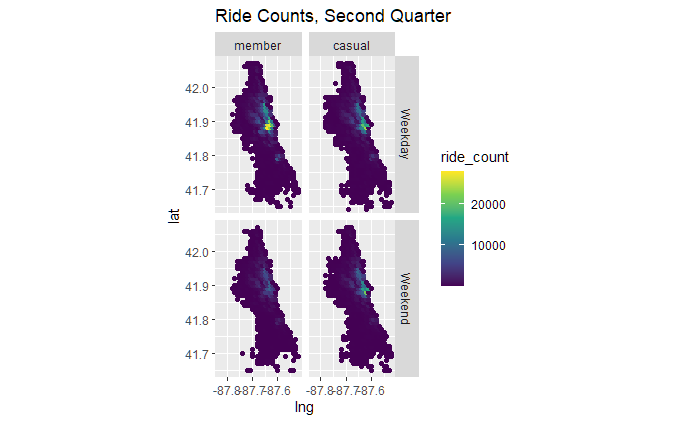

```r
bike_share %>%
  filter(start_quarter == 2) %>%
  group_by(lat, lng, member_casual, wkend) %>%
  summarize(ride_count = n(), .groups = "keep") %>%
  ggplot(mapping = aes(x = lng, y = lat)) +
  geom_point(mapping = aes(color = ride_count), size = 1.3) +
  scale_color_viridis_c() +
  bike_coord +
  facet_grid(wkend ~ member_casual) +
  ggtitle(label = "Ride Counts, Second Quarter")
```

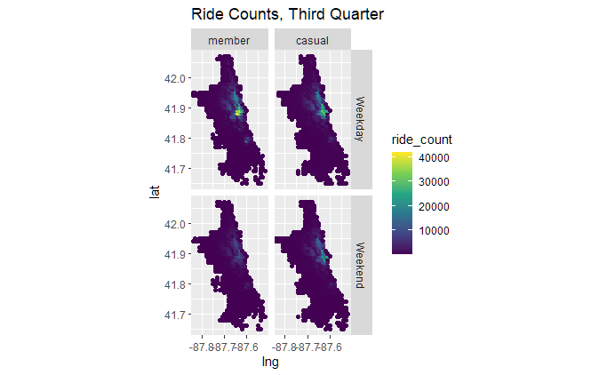

```r
bike_share %>%
  filter(start_quarter == 3) %>%
  group_by(lat, lng, member_casual, wkend) %>%
  summarize(ride_count = n(), .groups = "keep") %>%
  ggplot(mapping = aes(x = lng, y = lat)) +
  geom_point(mapping = aes(color = ride_count), size = 1.3) +
  scale_color_viridis_c() +
  bike_coord +
  facet_grid(wkend ~ member_casual) +
  ggtitle(label = "Ride Counts, Third Quarter")
```

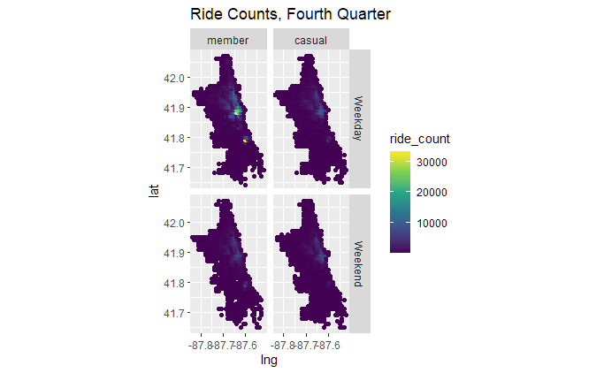

```r
bike_share %>%
  filter(start_quarter == 4) %>%
  group_by(lat, lng, member_casual, wkend) %>%
  summarize(ride_count = n(), .groups = "keep") %>%
  ggplot(mapping = aes(x = lng, y = lat)) +
  geom_point(mapping = aes(color = ride_count), size = 1.3) +
  scale_color_viridis_c() +
  bike_coord +
  facet_grid(wkend ~ member_casual) +
  ggtitle(label = "Ride Counts, Fourth Quarter")
```

Given that we know there were low numbers of rides by casual users in the first and fourth quarters, and given that casual riders are most active on weekends, there’s nothing unusual in these plots.

Another way to compare members and casual riders is to look at the percentages of rides by each group at each location. We’ll use a gradient of color from orange (0%) to blue (100%) to represent the percentage of rides at that were by casual riders.

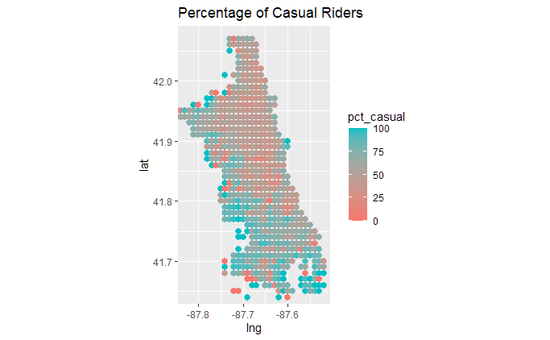

```r
bike_share %>%
  group_by(lat, lng) %>%
  summarize(
    pct_casual  = 100 * mean(member_casual == "casual"),
    count = n(),
    .groups = "keep"
  ) %>%
  ggplot(mapping = aes(x = lng, y = lat)) +
  geom_point(mapping = aes(color = pct_casual), size = 2.5) +
  scale_color_gradient(low = "#F8766D", high = "#00BFC4", limits = c(0, 100)) +
  bike_coord +
  ggtitle(label = "Percentage of Casual Riders")
```

The blue locations have high percentages of rides by casual riders, and the orange locations have low percentages of rides by casual riders.

There are many locations in the south and west of the city that have high percentages of casual riders. But we have to consider that these locations may not have high numbers of rides. Let’s plot only locations that average no more than two rides per day.

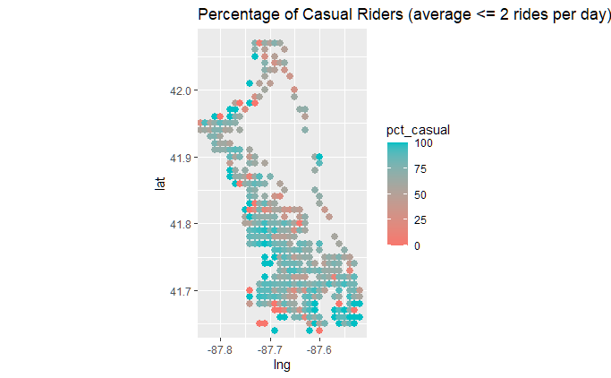

```r
bike_share %>%
  group_by(lat, lng) %>%
  summarize(
    pct_casual  = 100 * mean(member_casual == "casual"),
    count = n(),
    .groups = "keep"
  ) %>%
  filter(count <= 365 * 2) %>%
  ggplot(mapping = aes(x = lng, y = lat)) +
  geom_point(mapping = aes(color = pct_casual), size = 2.5) +
  scale_color_gradient(low = "#F8766D", high = "#00BFC4", limits = c(0, 100)) +
  bike_coord +
  ggtitle(label = "Percentage of Casual Riders (average <= 2 rides per day)")
```

These locations are the majority, but they represent a small proportion of the total rides. There are 383 points on this plot, and even if each point had an average of two rides per day, they would represent less than 280,000 of the over 5.5 million total rides.

Let’s look at the locations which average more than ten rides a day.

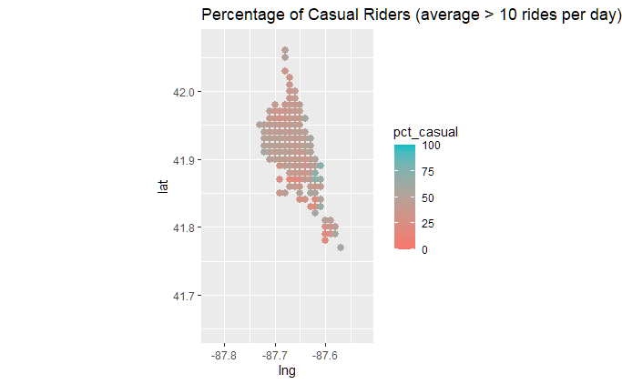

```r
bike_share %>%
  group_by(lat, lng) %>%
  summarize(
    pct_casual  = 100 * mean(member_casual == "casual"),
    count = n(),
    .groups = "keep"
  ) %>%
  filter(count > 365 * 10) %>%
  ggplot(mapping = aes(x = lng, y = lat)) +
  geom_point(mapping = aes(color = pct_casual), size = 2.5) +
  scale_color_gradient(low = "#F8766D", high = "#00BFC4", limits = c(0, 100)) +
  bike_coord +
  ggtitle(label = "Percentage of Casual Riders (average > 10 rides per day)")
```

There are some locations along the lake shore where casual riders predominate. Let’s look at this plot by quarter, and make separate plots for weekdays and weekends.

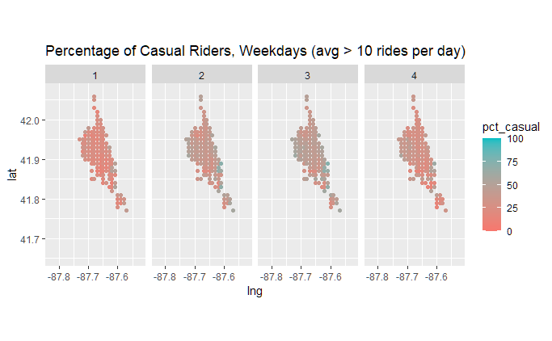

```r
bike_share %>%
  group_by(lat, lng) %>%
  mutate(count = n()) %>%
  filter(count > 365 * 10) %>%
  ungroup() %>%
  filter(wkend == "Weekday") %>%
  group_by(start_quarter, lat, lng) %>%
  summarize(
    pct_casual  = 100 * mean(member_casual == "casual"),
    .groups = "keep"
  ) %>%
  ggplot(mapping = aes(x = lng, y = lat)) +
  geom_point(mapping = aes(color = pct_casual), size = 1.5) +
  scale_color_gradient(low = "#F8766D", high = "#00BFC4", limits = c(0, 100)) +
  bike_coord +
  ggtitle(
    label = "Percentage of Casual Riders, Weekdays (avg > 10 rides per day)"
  ) +
  facet_wrap(~ start_quarter, nrow = 1)
```

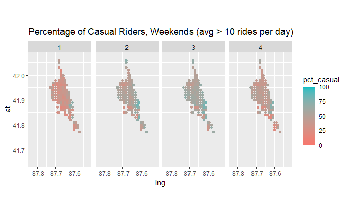

```r
bike_share %>%
  group_by(lat, lng) %>%
  mutate(count = n()) %>%
  filter(count > 365 * 10) %>%
  ungroup() %>%
  filter(wkend == "Weekend") %>%
  group_by(start_quarter, lat, lng) %>%
  summarize(
    pct_casual  = 100 * mean(member_casual == "casual"),
    .groups = "keep"
  ) %>%
  ggplot(mapping = aes(x = lng, y = lat)) +
  geom_point(mapping = aes(color = pct_casual), size = 1.5) +
  scale_color_gradient(low = "#F8766D", high = "#00BFC4", limits = c(0, 100)) +
  bike_coord +
  ggtitle(
    label = "Percentage of Casual Riders, Weekends (avg > 10 rides per day)"
  ) +
  facet_wrap(~ start_quarter, nrow = 1)
```

Members dominate in the first and fourth quarters, as expected. But in all quarters there are locations along the lake shore where casual riders dominate, especially on weekends.

Another way to look for locations with unusual percentages of casual riders is calculate how much the percentage of casual rides at each location differs from the quarterly average for all locations. We’ll do this for each quarter, for weekdays and weekends. We’ll also zoom in.

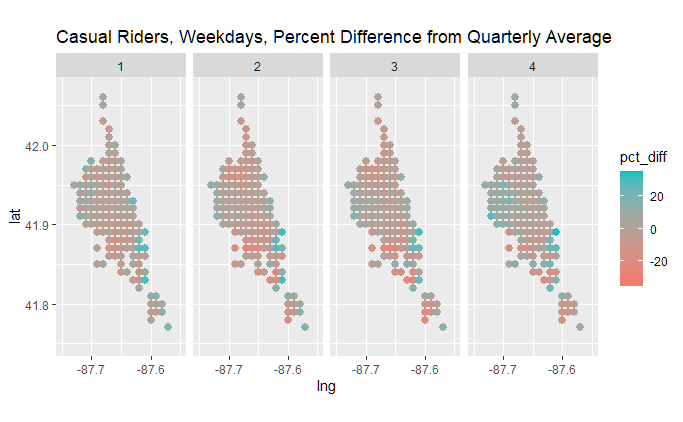

```r
bike_share %>%
  group_by(lat, lng) %>%
  mutate(count = n()) %>%
  filter(count > 365 * 10) %>%
  ungroup() %>%
  filter(wkend == "Weekday") %>%
  group_by(start_quarter) %>%
  mutate(pct_casual_overall = 100 * mean(member_casual == "casual"))  %>%
  group_by(start_quarter, pct_casual_overall, lat, lng) %>%
  summarize(
    pct_casual  = 100 * mean(member_casual == "casual"),
    count = n(),
    .groups = "keep"
  ) %>%
  ungroup() %>%
  mutate(pct_diff = pct_casual - pct_casual_overall) %>%
  ggplot(mapping = aes(x = lng, y = lat)) +
  geom_point(mapping = aes(color = pct_diff), size = 2.5) +
  scale_x_continuous(breaks = c(-87.7, -87.6)) +
  scale_color_gradient(low = "#F8766D", high = "#00BFC4", limits = c(-35, 35)) +
  coord_quickmap(xlim = c(-87.75, -87.55), ylim = c(41.75, 42.07)) +
  facet_wrap(~ start_quarter, nrow = 1) +
  ggtitle(
    label = "Casual Riders, Weekdays, Percent Difference from Quarterly Average"
  )
```

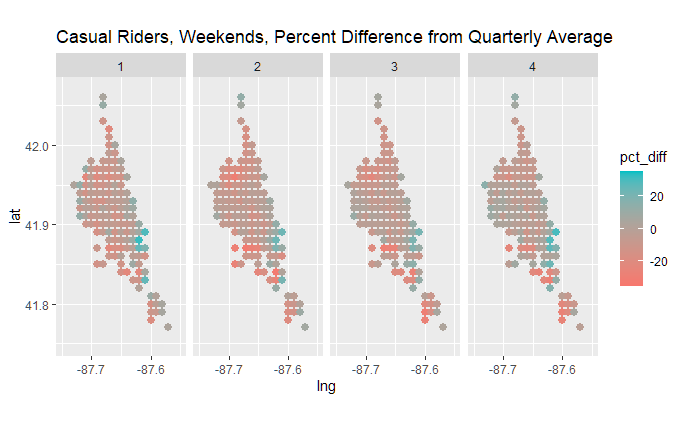

```r
bike_share %>%
  group_by(lat, lng) %>%
  mutate(count = n()) %>%
  filter(count > 365 * 10) %>%
  ungroup() %>%
  filter(wkend == "Weekend") %>%
  group_by(start_quarter) %>%
  mutate(pct_casual_overall = 100 * mean(member_casual == "casual"))  %>%
  group_by(start_quarter, pct_casual_overall, lat, lng) %>%
  summarize(
    pct_casual  = 100 * mean(member_casual == "casual"),
    count = n(),
    .groups = "keep"
  ) %>%
  ungroup() %>%
  mutate(pct_diff = pct_casual - pct_casual_overall) %>%
  ggplot(mapping = aes(x = lng, y = lat)) +
  geom_point(mapping = aes(color = pct_diff), size = 2.5) +
  scale_x_continuous(breaks = c(-87.7, -87.6)) +
  scale_color_gradient(low = "#F8766D", high = "#00BFC4", limits = c(-35, 35)) +
  coord_quickmap(xlim = c(-87.75, -87.55), ylim = c(41.75, 42.07)) +
  facet_wrap(~ start_quarter, nrow = 1) +
  ggtitle(
    label = "Casual Riders, Weekends, Percent Difference from Quarterly Average"
  )
```

In these plots the blue to orange scale indicates the extent to which the percentage of casual riders at the location is above or below the percentage of total casual riders for that quarter.

What stands out in these plots is that casual riders dominate in areas near the lake shore in the city center, in all quarters and on both weekdays and weekends, and members consistently dominate in areas of the city center just west of the lake shore.

# Analysis - Ride Displacement

Let’s see whether there are any significant differences in ride displacement between members and casual riders. We’ll look at boxplots for weekdays and weekends.

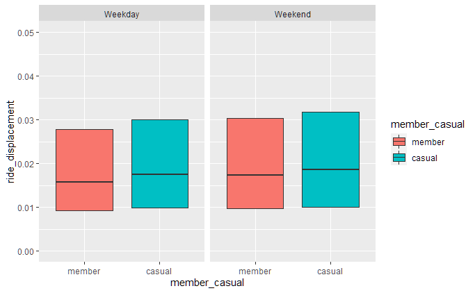

```r
bike_share %>%
  filter(!is.na(ride_displacement)) %>%
  ggplot(mapping = aes(x = member_casual, y = ride_displacement) ) +
  geom_boxplot(
    mapping = aes(group = member_casual, fill = member_casual),
    position = "dodge",
    outlier.shape = NA,
    coef = 0,
  ) +
  facet_wrap(~ wkend) +
  coord_cartesian(ylim = c(0, 0.05))
```

The difference between the groups is slight. Let’s look at monthly and hourly boxplots.

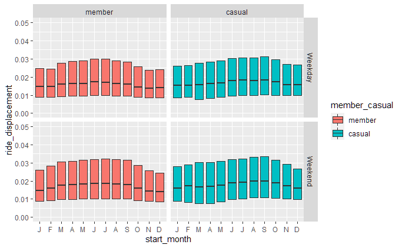

```r
bike_share %>%
  filter(!is.na(ride_displacement)) %>%
  ggplot(mapping = aes(x = start_month, y = ride_displacement) ) +
  geom_boxplot(
    mapping = aes(group = start_month, fill = member_casual),
    position = "dodge",
    outlier.shape = NA,
    coef = 0,
  ) +
  scale_x_discrete(labels = substr(levels(bike_share$start_month), 1, 1)) +
  facet_grid(wkend ~ member_casual) +
  coord_cartesian(ylim = c(0, 0.05))
```

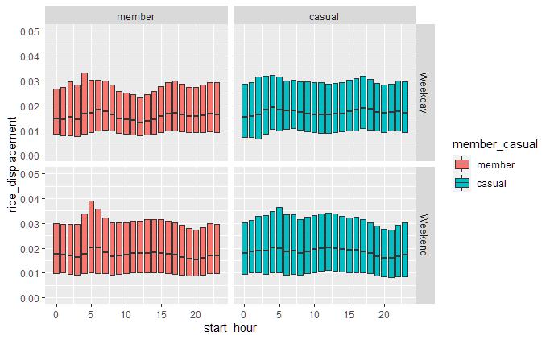

```r
bike_share %>%
  filter(!is.na(ride_displacement)) %>%
  ggplot(mapping = aes(x = start_hour, y = ride_displacement) ) +
  geom_boxplot(
    mapping = aes(group = start_hour, fill = member_casual),
    position = "dodge",
    outlier.shape = NA,
    coef = 0,
  ) +
  facet_grid(wkend ~ member_casual) +
  coord_cartesian(ylim = c(0, 0.05))
```

There’s not a notable difference in ride displacement between the two groups.